# InVivoStat Single Measure Parametric Analysis

## Response

The Resp 1 response is currently being analysed by the Single Measures Parametric Analysis module.

## Scatterplot of the observed data

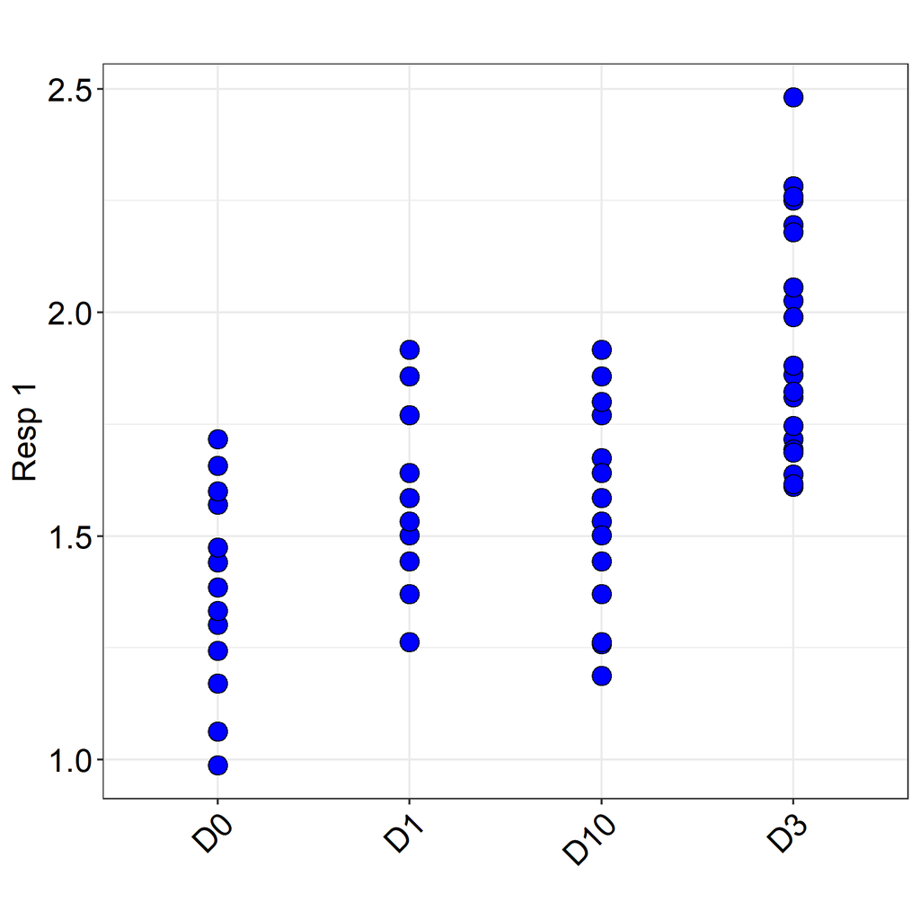

Tip: Use this plot to identify possible outliers.

## Analysis of variance (ANOVA) table

| Effect | Sums of squares | Degrees of freedom | Mean square | F-value | p-value |
| --- | --- | --- | --- | --- | --- |
| Treat1 | 3.068 | 3 | 1.023 | 18.60 | < 0.0001 |
| Residual | 4.069 | 74 | 0.055 |  |  |

Comment: ANOVA table calculated using a Type III model fit, see Armitage et al. (2001).

Conclusion: At the 5% level, there is a statistically significant overall difference between the levels of Treat1.

Tip: While it is a good idea to consider the overall tests in the ANOVA table, we should not rely on them when deciding whether or not to make pairwise comparisons.

## Model coefficients

|  | Estimate | Std. Error | t-value | p-value |
| --- | --- | --- | --- | --- |
| (Intercept) | 1.6159 | 0.0266 | 60.80 | < 0.0001 |
| Treat11 | -0.2174 | 0.0473 | -4.60 | < 0.0001 |
| Treat12 | -0.0520 | 0.0456 | -1.14 | 0.2575 |
| Treat13 | -0.0550 | 0.0456 | -1.20 | 0.2321 |

## Diagnostic plots

### Residuals vs. predicted plot

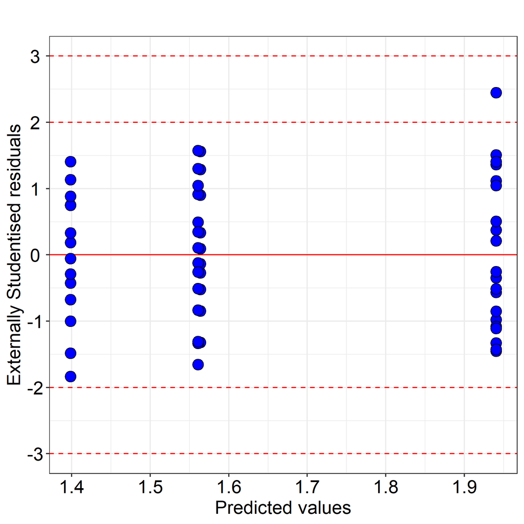

Tip: On this plot look to see if the spread of the points increases as the predicted values increase. If so the response may need transforming.

Tip: Any observation with a residual less than -3 or greater than 3 (SD) should be investigated as a possible outlier.

### Normal probability plot

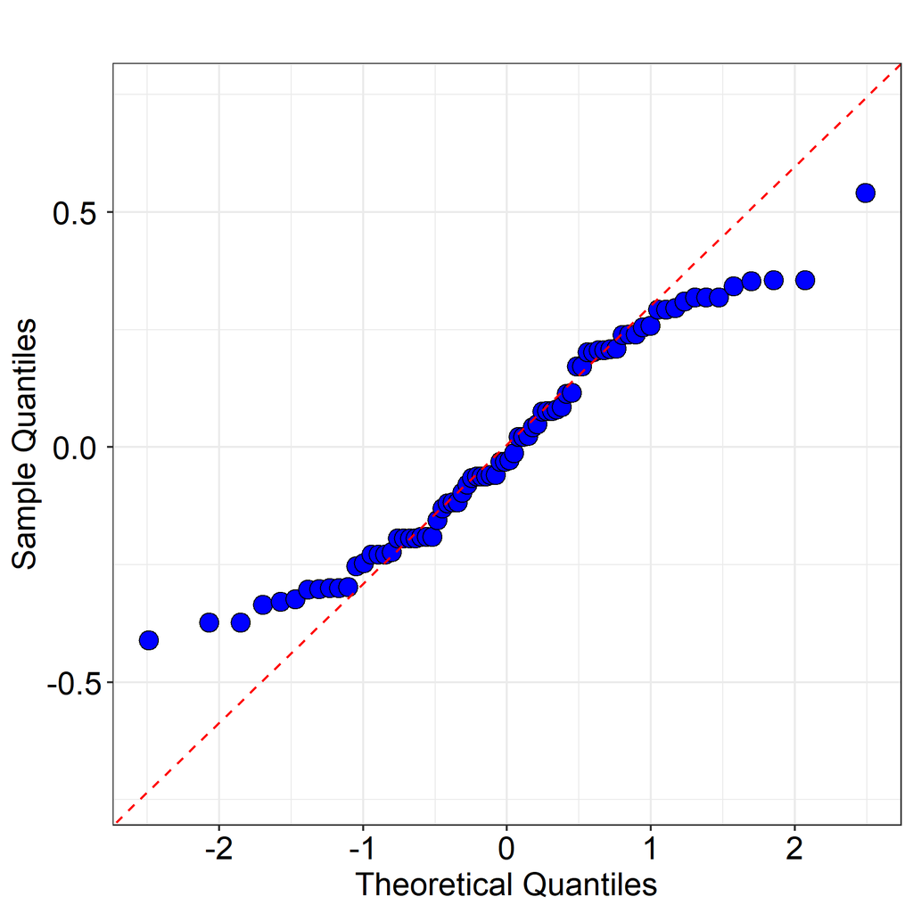

Tip: Check that the points lie along the dotted line. If not then the data may be non-normally distributed.

## Table of the least square (predicted) means with 95% confidence intervals

| Mean ID | Treat1 | Mean | Lower 95% CI | Upper 95% CI |
| --- | --- | --- | --- | --- |
| 1 | D0 | 1.399 | 1.288 | 1.509 |
| 2 | D1 | 1.564 | 1.459 | 1.668 |
| 3 | D10 | 1.561 | 1.457 | 1.665 |
| 4 | D3 | 1.940 | 1.836 | 2.045 |

## Plot of the least square (predicted) means with 95% confidence intervals

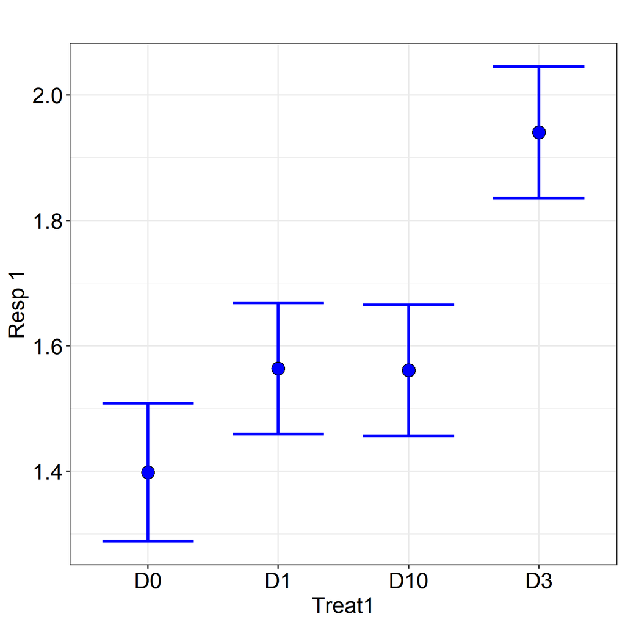

## All pairwise comparisons without adjustment for multiplicity (LSD test)

| Comparison | Difference | Lower 95% CI | Upper 95% CI | Std error | p-value |
| --- | --- | --- | --- | --- | --- |
| D0 - D1 | -0.165 | -0.317 | -0.014 | 0.076 | 0.0332 |
| D0 - D10 | -0.162 | -0.314 | -0.011 | 0.076 | 0.0363 |
| D0 - D3 | -0.542 | -0.694 | -0.390 | 0.076 | < 0.0001 |
| D1 - D10 | 0.003 | -0.145 | 0.151 | 0.074 | 0.9687 |
| D1 - D3 | -0.376 | -0.524 | -0.229 | 0.074 | < 0.0001 |
| D10 - D3 | -0.379 | -0.527 | -0.232 | 0.074 | < 0.0001 |

Conclusion: The following pairwise comparisons are statistically significant at the 5% level: (1) D0 - D1, (2) D0 - D10, (3) D0 - D3, (4) D1 - D3, (5) D10 - D3.

Warning: As these tests are not adjusted for multiplicity there is a risk of generating false positive results. Only use the pairwise tests you planned to make a-priori, these are the so called planned comparisons, see Snedecor and Cochran (1989).

## All to one comparisons without adjustment for multiplicity (LSD test)

| Comparison | Difference | Lower 95% CI | Upper 95% CI | Std error | p-value |
| --- | --- | --- | --- | --- | --- |
| D1 - D0 | 0.165 | 0.014 | 0.317 | 0.076 | 0.0332 |
| D10 - D0 | 0.162 | 0.011 | 0.314 | 0.076 | 0.0363 |
| D3 - D0 | 0.542 | 0.390 | 0.694 | 0.076 | < 0.0001 |

## Plot of the comparisons between the predicted means with 95% confidence intervals

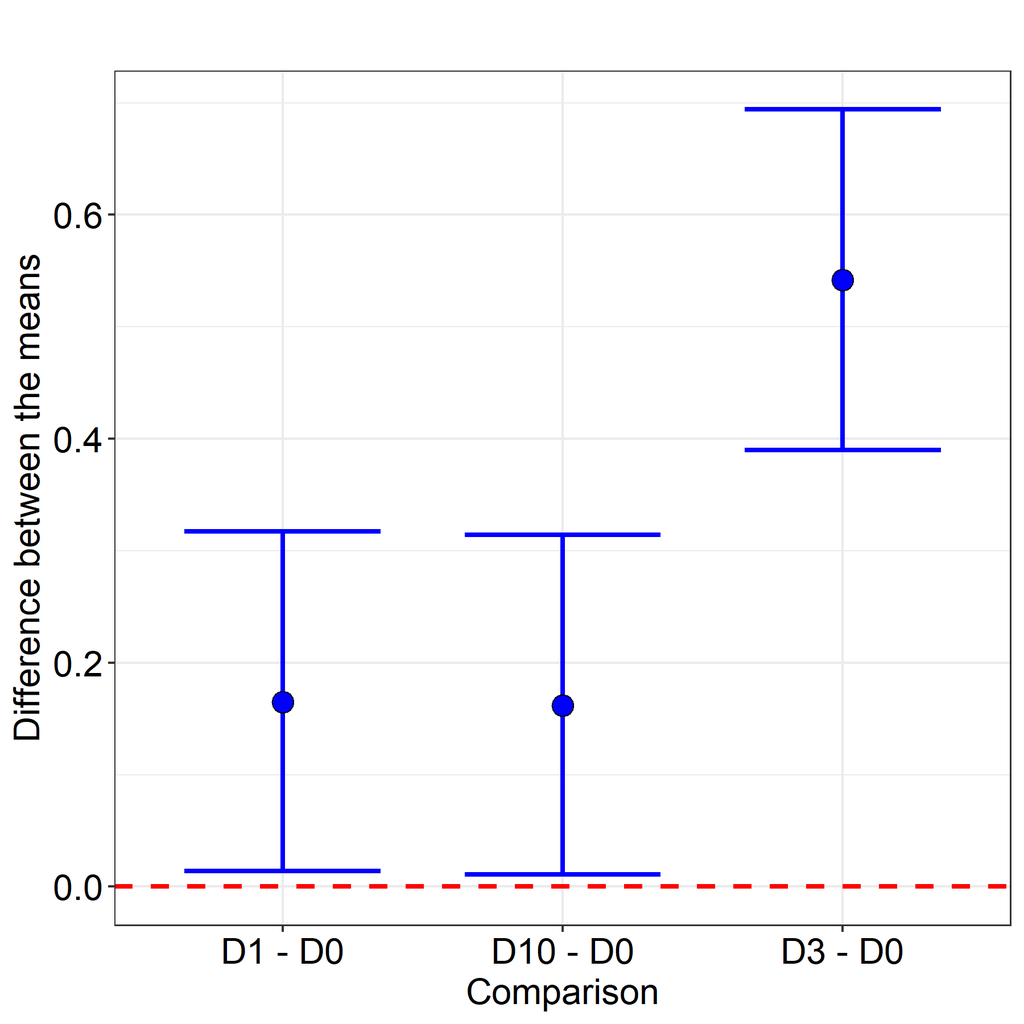

Conclusion: The following pairwise comparisons are statistically significant at the 5% level: (1) D1 - D0, (2) D10 - D0, (3) D3 - D0.

Warning: As these tests are not adjusted for multiplicity there is a risk of generating false positive results. Only use the pairwise tests you planned to make a-priori, these are the so called planned comparisons, see Snedecor and Cochran (1989).

## Analysis description

The data were analysed using a 1-way ANOVA approach, with Treat1 as the treatment factor. This was followed by Planned Comparisons of the predicted means to compare the levels of the Treat1 factor, Snedecor and Cochran (1989).

For more information on the theoretical approaches that are implemented within this module, see Bate and Clark (2014).

## References

When referring to InVivoStat, please cite 'InVivoStat, version 5.2.0'.

Bate, S.T. and Clark, R.A. (2014). The Design and Statistical Analysis of Animal Experiments. Cambridge University Press.

Armitage, P., Matthews, J.N.S. and Berry, G. (2001). Statistical Methods in Medical Research. 4th edition; John Wiley & Sons. New York.

Snedecor, G.W. and Cochran, W.G. (1989). Statistical Methods. 8th edition; Iowa State University Press, Iowa, USA.